# Project 2 QuantFund

Student Name_Student ID: Hu Lingzhen_1155146522; Ye Kaixin_1155153576; Zhou Yanxuting_1155151493; Wang Ziwei_1155147399; Hu Yuxuan_1155153427

```python
import pandas as pd
import os
from scipy import stats
import numpy as np
from os import listdir
```

## Preparation: Calculate the forward returns for stocks and market indices

```python
csv_path = "0 Data/"
stockclose = "StockClosePrice"
indexclose = "IndexClosePrice"

forward_day = 5 # this should depend on your rolling period

# calculate the forward returns
stock = pd.read_csv(csv_path + stockclose + ".csv", index_col = 0, parse_dates = True)
stockforward = stock.shift(periods = -forward_day, freq = None, axis = 0)
# 5Dforward(t) = (close_price(t+5)-close_price(t))/close_price(t)
stockforwardreturn = (stockforward - stock) / stock
print(stockforwardreturn.head())
stockforwardreturn.to_csv(os.path.join(csv_path, '5DForward.csv')) #stock

# In the simulation,
# you should also calculate indices returns,
# and hedge your portfolio with any one of them.
index = pd.read_csv(csv_path + indexclose + ".csv", index_col = 0, parse_dates = True)
indexforward = index.shift(periods = -forward_day, freq = None, axis = 0)
indexforwardreturn = (indexforward - index) / index
print(indexforwardreturn.head())
indexforwardreturn.to_csv(os.path.join(csv_path, 'mkt_5DForward.csv')) #mkt
```

```
            000001.SZ  000002.SZ  000004.SZ  000005.SZ  000006.SZ  000007.SZ  \
date
2007-01-04   0.047482   0.061368   0.088638   0.186231   0.065688   0.122858
2007-01-05   0.188363   0.084177   0.094316   0.107551  -0.016348   0.037043
2007-01-08   0.219149   0.158273   0.103618   0.111985   0.006898   0.031495
2007-01-09   0.233333   0.230769   0.096691   0.135329   0.075422   0.031128
2007-01-10   0.208806   0.006994   0.083142   0.096759  -0.043272   0.007674

            000008.SZ  000009.SZ  000010.SZ  000011.SZ  ...  603987.SH  \
date                                                    ...
2007-01-04   0.250000   0.125307        0.0   0.128390  ...        NaN
2007-01-05   0.122891   0.073622        0.0   0.079454  ...        NaN
2007-01-08   0.140277   0.086213        0.0   0.092567  ...        NaN
2007-01-09   0.130120   0.044423        0.0   0.123708  ...        NaN
2007-01-10   0.000000  -0.026172        0.0   0.017069  ...        NaN

            603988.SH  603989.SH  603990.SH  603991.SH  603993.SH  603996.SH  \
date
2007-01-04        NaN        NaN        NaN        NaN        NaN        NaN
2007-01-05        NaN        NaN        NaN        NaN        NaN        NaN
2007-01-08        NaN        NaN        NaN        NaN        NaN        NaN
2007-01-09        NaN        NaN        NaN        NaN        NaN        NaN
2007-01-10        NaN        NaN        NaN        NaN        NaN        NaN

            603997.SH  603998.SH  603999.SH
date
2007-01-04        NaN        NaN        NaN
2007-01-05        NaN        NaN        NaN
2007-01-08        NaN        NaN        NaN
2007-01-09        NaN        NaN        NaN
2007-01-10        NaN        NaN        NaN

[5 rows x 3584 columns]
            SH000001  SH000300  SH000905  SH000906
2007-04-01  0.049606  0.079600  0.132588  0.091227
2007-05-01  0.033619  0.048662  0.062853  0.051875
2007-08-01  0.057388  0.073083  0.072668  0.073045
2007-09-01  0.030958  0.069897  0.086235  0.073611
2007-10-01 -0.004019  0.023475  0.048856  0.029213
```

## Read the factors

```python
#factor_folder = "0 Data/0 Sample_factors/" # I am only using several sample factors here. You should try all factors
factor_folder = "0 Data/0 ALL_factors/"
factor_list = list(set(os.listdir(factor_folder)) - set(['.DS_Store']))
factor_list.sort()
factor_list

# Read all factor files
# Remeber to Z-score the factor values to remove the scale differences
dfs = []
i = 0
for factor in factor_list:
    dfs.append(factor)
    df = pd.read_csv(factor_folder + factor , index_col = 0, parse_dates = True)
    dfs[i] = (df - df.mean()) / df.std()
    i = i + 1

print(dfs[0].head())
```

```
            000001.SZ  000002.SZ  000004.SZ  000005.SZ  000006.SZ  000007.SZ  \
date
2008-01-02  -0.992037  -1.363952  -0.910292   0.025391  -1.526481  -0.743263
2008-01-03  -0.991141  -1.367213  -0.887059   0.039176  -1.522457  -0.715312
2008-01-04  -0.986487  -1.352934  -0.880362   0.028740  -1.518978  -0.720727
2008-01-07  -0.981773  -1.340274  -0.862626   0.057754  -1.512180  -0.707611
2008-01-08  -0.981442  -1.349670  -0.868896   0.042720  -1.519015  -0.733217

            000008.SZ  000009.SZ  000010.SZ  000011.SZ  ...  603987.SH  \
date                                                    ...
2008-01-02  -0.918841  -0.308051        NaN  -1.442556  ...        NaN
2008-01-03  -0.918733  -0.310627        NaN  -1.439407  ...        NaN
2008-01-04  -0.909876  -0.316198        NaN  -1.437608  ...        NaN
2008-01-07  -0.915067  -0.322559        NaN  -1.438576  ...        NaN
2008-01-08  -0.916320  -0.335895        NaN  -1.443508  ...        NaN

            603988.SH  603989.SH  603990.SH  603991.SH  603993.SH  603996.SH  \
date
2008-01-02        NaN        NaN        NaN        NaN        NaN        NaN
2008-01-03        NaN        NaN        NaN        NaN        NaN        NaN
2008-01-04        NaN        NaN        NaN        NaN        NaN        NaN
2008-01-07        NaN        NaN        NaN        NaN        NaN        NaN
2008-01-08        NaN        NaN        NaN        NaN        NaN        NaN

            603997.SH  603998.SH  603999.SH
date
2008-01-02        NaN        NaN        NaN
2008-01-03        NaN        NaN        NaN
2008-01-04        NaN        NaN        NaN
2008-01-07        NaN        NaN        NaN
2008-01-08        NaN        NaN        NaN

[5 rows x 3569 columns]
```

## Re-organize the data

Here we need to re-organize the data for use. I build distinct dataframe for each stock and concat them all.

```python
#list all the factors,
factors = ['return'] #
for i in range(len(factor_list)):
    factors.append(factor_list[i][:-4])

#match the data of return and factor
return_cut = stockforwardreturn[dfs[0].columns][dfs[0].index[0]:dfs[0].index[-1]]
```

```python
#Here we use the temp we run and save in the first time, so this part of code hasn't been run since that.

#Construct each stock's dataset
data_trans=[]
for i in range(return_cut.shape[1]):
    temp = return_cut.iloc[:,i:i+1]
    data_trans.append(temp)
    for j in range(len(dfs)):
        temp = pd.concat([temp,dfs[j].iloc[:,i:i+1]],axis=1)
    temp.set_axis(factors, axis='columns', inplace=True)
    temp['index']=range(1,len(temp)+1)
    temp['index']=temp['index'].apply(lambda x:str(i+1)+','+str(x))
    temp.set_index(['index'],inplace=True)
    data_trans[i] = temp

#concat all the stock's data together
temp=data_trans[0].copy()

for i in range(1,len(data_trans)):
    temp = pd.concat([temp,data_trans[i]],axis=0)

save_result_path =  '0 Data/'
temp.to_csv(os.path.join(save_result_path, 'temp.csv'))
```

```python
temp=pd.read_csv(r"D:\Project 2 QuantFund (Code+Data)\Project 2 QuantFund (Code+Data)\0 Data\temp.csv", index_col=0)
```

## Deal with the missing value

We should drop the dates with no return value, and fitler out the factors with too many missing values.

```python
data1 = temp.dropna(subset=['return'])

data1.isnull().sum()
```

```
return                            0
NonOperatingNPTTM             57824
SalesCostRatio                55640
PBIndu                        67716
SalesExpenseTTM              265382
PCFIndu                     1707994
TVMA6                        432426
LongTermDebtToAsset          151084
NonCurrentAssetsRatio        126400
PEIndu                       807595
RealizedVolatility           430857
InformationRatio120           22395
GainLossVarianceRatio20       43002
GREV                         866573
EMA26                        432427
SaleServiceRenderCashTTM     131601
ROAEBITTTM                   148433
GainVariance20                25574
STOM                         432435
MoneyFlow20                  442515
PE                            49924
SBM                          489222
Price1Y                      432432
ILLIQUIDITY                  425746
SUE                          390070
PEHist120                     49882
DAVOL20                      432555
REVS750                     1789595
TVSTD20                      434494
TVMA20                       432426
ROE5                         868469
PSIndu                        63901
AD                           439379
MktValue                      12825
PEHist60                      49882
FinancialExpenseRate         151802
ATR14                        439283
GainLossVarianceRatio60       43002
InformationRatio60            22395
DAREV                       1935887
GainVariance120               25574
GainLossVarianceRatio120      43002
VEMA10                       432427
InterestCover                454801
PEHist250                     49882
dtype: int64
```

```python
#drop factors with null values over 100000
core_factors = data1.isnull().sum()[data1.isnull().sum()<100000].index
data = data1[core_factors].dropna()
data
```

| index | return | NonOperatingNPTTM | SalesCostRatio | PBIndu | InformationRatio120 | GainLossVarianceRatio20 | GainVariance20 | PE | PEHist120 | PSIndu | MktValue | PEHist60 | GainLossVarianceRatio60 | InformationRatio60 | GainVariance120 | GainLossVarianceRatio120 | PEHist250 |
| --- | --- | --- | --- | --- | --- | --- | --- | --- | --- | --- | --- | --- | --- | --- | --- | --- | --- |
| 1,1 | 0.082412 | -0.135527 | 0.002267 | 0.124711 | 0.304820 | 0.130487 | 0.874219 | 1.054804 | -0.056532 | 0.561348 | -0.431592 | 0.064200 | 0.856878 | 0.111823 | 1.754985 | 0.616604 | 0.066059 |
| 1,2 | 0.123159 | -0.135527 | 0.002267 | 0.116186 | 0.032733 | 0.141101 | 0.874219 | 1.025210 | -0.087318 | 0.577248 | -0.458640 | 0.022581 | 0.869264 | -0.242802 | 1.754985 | 0.636665 | 0.038891 |
| 1,3 | 0.148814 | -0.135527 | 0.002267 | 0.118153 | 0.063689 | 0.143305 | 0.878537 | 1.073125 | -0.039740 | 0.561544 | -0.414848 | 0.106393 | 0.610174 | 0.023636 | 1.728368 | 0.614573 | 0.082297 |
| 1,4 | 0.109267 | -0.135527 | 0.002267 | 0.125039 | -0.034067 | 0.133320 | 0.859824 | 1.110701 | -0.002984 | 0.564489 | -0.380502 | 0.173845 | 0.616198 | 0.232845 | 1.703526 | 0.596417 | 0.116022 |
| 1,5 | 0.040604 | -0.135527 | 0.002267 | 0.137335 | 0.265718 | -0.150077 | 0.325796 | 1.168011 | 0.053177 | 0.589418 | -0.328124 | 0.270000 | 0.521690 | 0.391395 | 1.675135 | 0.574071 | 0.167547 |
| ... | ... | ... | ... | ... | ... | ... | ... | ... | ... | ... | ... | ... | ... | ... | ... | ... | ... |
| 3569,2553 | -0.057109 | -2.162958 | 2.280919 | -0.683128 | -0.039938 | -0.057881 | -0.116891 | -1.296425 | -0.474999 | -0.692197 | -1.500792 | -0.814628 | -0.059246 | -0.039937 | -0.450676 | -0.060791 | -0.516334 |
| 3569,2554 | -0.008637 | -2.162958 | 2.280919 | -0.774481 | -0.039938 | -0.057860 | -0.116891 | -1.369982 | -0.609030 | -0.784411 | -1.537064 | -0.956488 | -0.059212 | -0.039937 | -0.450676 | -0.060796 | -0.626891 |
| 3569,2555 | -0.020150 | -2.162958 | 2.280919 | -0.733168 | -0.039937 | -0.057930 | -0.119940 | -1.301021 | -0.472689 | -0.743649 | -1.503059 | -0.812719 | -0.059241 | -0.039937 | -0.450568 | -0.060793 | -0.512768 |
| 3569,2556 | -0.051044 | -2.162958 | 2.280919 | -0.709894 | -0.039937 | -0.057862 | -0.119940 | -1.333203 | -0.528150 | -0.722266 | -1.518928 | -0.874426 | -0.059250 | -0.039937 | -0.450568 | -0.060785 | -0.557602 |
| 3569,2557 | 0.000000 | -2.162958 | 2.280919 | -0.764007 | -0.039938 | -0.057851 | -0.119940 | -1.411362 | -0.670846 | -0.788420 | -1.557468 | -1.027737 | -0.059211 | -0.039937 | -0.450568 | -0.060790 | -0.675291 |

6047357 rows × 17 columns

## Training Factors

In this part, we use four different ways to train factors and get a new one:linear regression, support vector machine regression, random forest regression and XGboosting. In order to get a better result, we also use the GridSearchCV fuction to do the cross validation and find the better parameter.

## Linear Regression

```python
from sklearn import linear_model

#data = temp.dropna()

X = data.drop(['return'], axis=1)
Y = data['return']
```

```python
model = linear_model.LinearRegression()
model.fit(X, Y)

yhat=data[['return']].copy()
yhat['return']=model.predict(X)

temp1=temp[['return']].join(yhat,lsuffix=1)[['return']]

for i in range(return_cut.shape[1]):
    if i == 0:
        factors_reg = temp1[0:return_cut.shape[0]]
        factors_reg.insert(0,'date',return_cut.index)
        factors_reg.set_index(['date'],inplace=True)
    else:
        temp2 = temp1[i*return_cut.shape[0]:(i+1)*return_cut.shape[0]]
        temp2.insert(0,'date',return_cut.index)
        temp2.set_index(['date'],inplace=True)

        factors_reg = pd.concat([factors_reg,temp2],axis=1)

factors_reg.set_axis(return_cut.columns, axis='columns', inplace=True)

save_result_path =  '0 Data/0 new_factors/'
factors_reg.to_csv(os.path.join(save_result_path, 'Linear_Reg_factor.csv'))
```

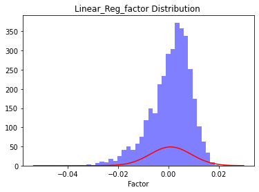

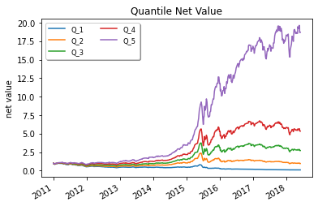

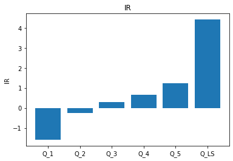

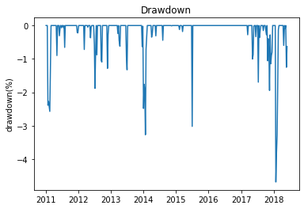

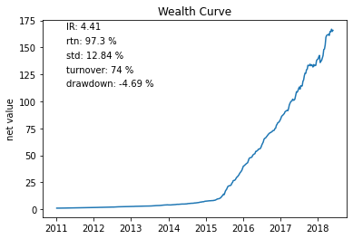

```python
# helper.py has all formulas and plotting functions
%run -i "helper.py"

# backtestlite.py has XXX
%run -i "backtestlite.py"

#set the working directory and some initial parameters.

working_directory = '0 Data/'
#Directory to import the factor you built
factor_path_all = '0 Data/0 New_factors/'

# Define the factor direction, (Descending or Ascending).
# The direction could be observed by the correlation between the factor your built and the stock returns.
# "Descending" if higher factor score, lower return
# "Ascending" if higher factor score, higher return
# direction = "Descending"
direction = "Ascending"
###############################################################

# Parameters of backtest.
start = '20110101' # Time horizon, can be vacation, progrmme will extract the maximum subset.
end = '20180601'
quantile = 5
cycle = 5 # Adjustment Cycle (trading frequency), delay for holidays.
win = 48 # 48 weeks in a year
year = 2011 # Beginning year of result display (graphs).

#Import stock 5days forward return.
fwdrtn = pd.read_csv(os.path.join(working_directory, "5DForward.csv"), index_col = 0, parse_dates = True).loc[start:end][::cycle]
#Import market 5days forward return.
mkt_index = pd.read_csv(os.path.join(working_directory, "mkt_5DForward.csv"), index_col = 0, parse_dates = True).loc[str(start):str(end),"SH000905"][::cycle]

#You might want to set trading status (whether it is tradable) when you work on bonus question
status = pd.DataFrame(1, index = fwdrtn.index, columns = fwdrtn.columns)
statuslimit = pd.DataFrame(1, index = fwdrtn.index, columns = fwdrtn.columns)

# Revise the factor name (name of .csv file)
factor =  "Linear_Reg_factor"

Type = "LS" # this stand for long-short strategy.
# Don't change this unless you are confident with the codes in backtestlite.py

def singlefactor(factor,factor_path_all,Type,direction,fwdrtn,mkt_index,cycle, start, end, quantile,win,year, statuslimit):
    factor_path = os.path.join(factor_path_all, factor + '.csv')

    Type1 = "LS"
    B = Backtestlite(factor_path, direction, fwdrtn, mkt_index, factor_path_all, cycle, start, end, quantile, statuslimit)
    B.run(Type1)

    # Drawing
    pic = DrawPicture(factor,direction, B.data,  B.fwdrtn, B.data.index , mkt_index,  B.rtn_data, B.coverage, B.turnover, factor_path_all, Type1)
    pic.main(win,year,B.rtn_data.columns)

# Calculate performances and do the plot
singlefactor(factor,factor_path_all,Type, direction,fwdrtn,mkt_index,cycle, start, end, quantile,win,year, statuslimit)
```

## SVR

Since the output——new factor is continuous number, we choose SVR instead of SVM to do this part, which we believe is more appropriate. The parameter of SVR mainly include kernel, C and gamma. Firstly, we use four different type of kernel with their default parameter to fit the model first. And by comparing the output plot generated by backtest file, we think using 'linear' can fit the model more accurate and get a better result. Then we use GridSearchCV to verify our guess and also choose the appropriate 'C'. Since 'linear' does not have the parameter 'gamma', we didn't add the 'gamma' into GridSearchCV. Hoewever, GridSearchCV output a different result: using 'rbf' and C as 0.1. We made two attempts: both using C as 0.1 but choosing different kernel: 'rbf' and 'linear'. Comparing the backtest output, 'linear' seems still perform better. So we choose linear in the end.

```python
from sklearn.svm import SVR
from sklearn.metrics import mean_squared_error
from sklearn.model_selection import GridSearchCV
```

```python
X = data.drop(['return'], axis=1)
Y = data['return']
```

```python
param_test = {'C':np.logspace(-1,1,3),'kernel':['linear','rbf','sigmoid']}
grid_search = GridSearchCV(estimator=SVR(max_iter=1000), param_grid=param_test, cv=5, n_jobs=60, scoring='neg_mean_squared_error')
grid_result=grid_search.fit(X, Y)
print(f'Best:{grid_result.best_score_}using{grid_result.best_params_}','\n')
```

```
Best:-0.0119549200254154using{'C': 0.1, 'kernel': 'rbf'}
```

```python
model = SVR(kernel='rbf',C=0.1,max_iter=1000)
model.fit(X, Y)

yhat=data[['return']].copy()
yhat['return']=model.predict(X)

temp1=temp[['return']].join(yhat,lsuffix=1)[['return']]

for i in range(return_cut.shape[1]):
    if i == 0:
        factors_reg = temp1[0:return_cut.shape[0]]
        factors_reg.insert(0,'date',return_cut.index)
        factors_reg.set_index(['date'],inplace=True)
    else:
        temp2 = temp1[i*return_cut.shape[0]:(i+1)*return_cut.shape[0]]
        temp2.insert(0,'date',return_cut.index)
        temp2.set_index(['date'],inplace=True)

        factors_reg = pd.concat([factors_reg,temp2],axis=1)

factors_reg.set_axis(return_cut.columns, axis='columns', inplace=True)

save_result_path =  '0 Data/0 new_factors/'
factors_reg.to_csv(os.path.join(save_result_path, 'SVR_rbf_factor.csv'))
```

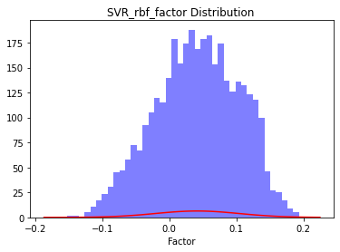

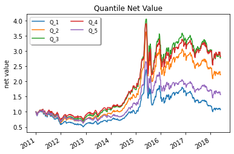

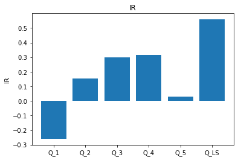

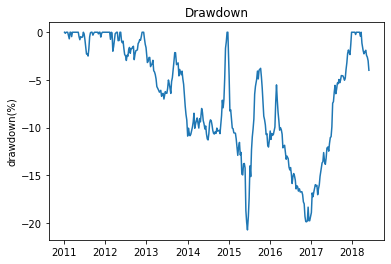

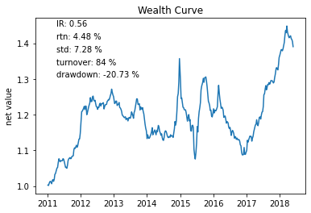

```python
# helper.py has all formulas and plotting functions
%run -i "helper.py"

# backtestlite.py has XXX
%run -i "backtestlite.py"

#set the working directory and some initial parameters.

working_directory = '0 Data/'
#Directory to import the factor you built
factor_path_all = '0 Data/0 New_factors/'

# Define the factor direction, (Descending or Ascending).
# The direction could be observed by the correlation between the factor your built and the stock returns.
# "Descending" if higher factor score, lower return
# "Ascending" if higher factor score, higher return
# direction = "Descending"
direction = "Ascending"
###############################################################

# Parameters of backtest.
start = '20110101' # Time horizon, can be vacation, progrmme will extract the maximum subset.
end = '20180601'
quantile = 5
cycle = 5 # Adjustment Cycle (trading frequency), delay for holidays.
win = 48 # 48 weeks in a year
year = 2011 # Beginning year of result display (graphs).

#Import stock 5days forward return.
fwdrtn = pd.read_csv(os.path.join(working_directory, "5DForward.csv"), index_col = 0, parse_dates = True).loc[start:end][::cycle]
#Import market 5days forward return.
mkt_index = pd.read_csv(os.path.join(working_directory, "mkt_5DForward.csv"), index_col = 0, parse_dates = True).loc[str(start):str(end),"SH000905"][::cycle]

#You might want to set trading status (whether it is tradable) when you work on bonus question
status = pd.DataFrame(1, index = fwdrtn.index, columns = fwdrtn.columns)
statuslimit = pd.DataFrame(1, index = fwdrtn.index, columns = fwdrtn.columns)

# Revise the factor name (name of .csv file)
factor =  "SVR_rbf_factor"

Type = "LS" # this stand for long-short strategy.
# Don't change this unless you are confident with the codes in backtestlite.py

def singlefactor(factor,factor_path_all,Type,direction,fwdrtn,mkt_index,cycle, start, end, quantile,win,year, statuslimit):
    factor_path = os.path.join(factor_path_all, factor + '.csv')

    Type1 = "LS"
    B = Backtestlite(factor_path, direction, fwdrtn, mkt_index, factor_path_all, cycle, start, end, quantile, statuslimit)
    B.run(Type1)

    # Drawing
    pic = DrawPicture(factor,direction, B.data,  B.fwdrtn, B.data.index , mkt_index,  B.rtn_data, B.coverage, B.turnover, factor_path_all, Type1)
    pic.main(win,year,B.rtn_data.columns)

# Calculate performances and do the plot
singlefactor(factor,factor_path_all,Type, direction,fwdrtn,mkt_index,cycle, start, end, quantile,win,year, statuslimit)
```

```python
model = SVR(kernel='linear',C=0.1,max_iter=1000)
model.fit(X, Y)

yhat=data[['return']].copy()
yhat['return']=model.predict(X)
```

```python
temp1=temp[['return']].join(yhat,lsuffix=1)[['return']]

for i in range(return_cut.shape[1]):
    if i == 0:
        factors_reg = temp1[0:return_cut.shape[0]]
        factors_reg.insert(0,'date',return_cut.index)
        factors_reg.set_index(['date'],inplace=True)
    else:
        temp2 = temp1[i*return_cut.shape[0]:(i+1)*return_cut.shape[0]]
        temp2.insert(0,'date',return_cut.index)
        temp2.set_index(['date'],inplace=True)

        factors_reg = pd.concat([factors_reg,temp2],axis=1)

factors_reg.set_axis(return_cut.columns, axis='columns', inplace=True)

save_result_path =  '0 Data/0 new_factors/'
factors_reg.to_csv(os.path.join(save_result_path, 'SVR_Linear_factor.csv'))
```

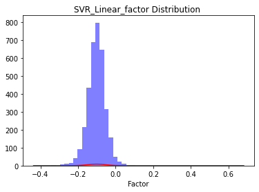

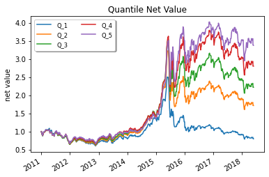

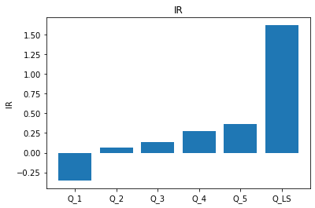

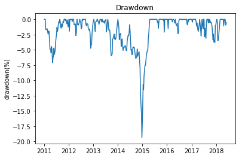

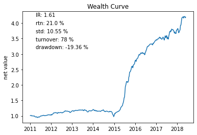

```python
# helper.py has all formulas and plotting functions
%run -i "helper.py"

# backtestlite.py has XXX
%run -i "backtestlite.py"

#set the working directory and some initial parameters.

working_directory = '0 Data/'
#Directory to import the factor you built
factor_path_all = '0 Data/0 New_factors/'

# Define the factor direction, (Descending or Ascending).
# The direction could be observed by the correlation between the factor your built and the stock returns.
# "Descending" if higher factor score, lower return
# "Ascending" if higher factor score, higher return
# direction = "Descending"
direction = "Ascending"
###############################################################

# Parameters of backtest.
start = '20110101' # Time horizon, can be vacation, progrmme will extract the maximum subset.
end = '20180601'
quantile = 5
cycle = 5 # Adjustment Cycle (trading frequency), delay for holidays.
win = 48 # 48 weeks in a year
year = 2011 # Beginning year of result display (graphs).

#Import stock 5days forward return.
fwdrtn = pd.read_csv(os.path.join(working_directory, "5DForward.csv"), index_col = 0, parse_dates = True).loc[start:end][::cycle]
#Import market 5days forward return.
mkt_index = pd.read_csv(os.path.join(working_directory, "mkt_5DForward.csv"), index_col = 0, parse_dates = True).loc[str(start):str(end),"SH000905"][::cycle]

#You might want to set trading status (whether it is tradable) when you work on bonus question
status = pd.DataFrame(1, index = fwdrtn.index, columns = fwdrtn.columns)
statuslimit = pd.DataFrame(1, index = fwdrtn.index, columns = fwdrtn.columns)

# Revise the factor name (name of .csv file)
factor =  "SVR_Linear_factor"

Type = "LS" # this stand for long-short strategy.
# Don't change this unless you are confident with the codes in backtestlite.py

def singlefactor(factor,factor_path_all,Type,direction,fwdrtn,mkt_index,cycle, start, end, quantile,win,year, statuslimit):
    factor_path = os.path.join(factor_path_all, factor + '.csv')

    Type1 = "LS"
    B = Backtestlite(factor_path, direction, fwdrtn, mkt_index, factor_path_all, cycle, start, end, quantile, statuslimit)
    B.run(Type1)

    # Drawing
    pic = DrawPicture(factor,direction, B.data,  B.fwdrtn, B.data.index , mkt_index,  B.rtn_data, B.coverage, B.turnover, factor_path_all, Type1)
    pic.main(win,year,B.rtn_data.columns)

# Calculate performances and do the plot
singlefactor(factor,factor_path_all,Type, direction,fwdrtn,mkt_index,cycle, start, end, quantile,win,year, statuslimit)
```

# Random forest regression

We also try random forest to build a new factor. Because the dependent variable is continuous, we use random forest regression. Before training, we first do cross-validation to choose the best parameter. After searching material, we decide to find best 'max_depth','min_samples_split',and 'n_estimators', which influnced most on the model. The GridSearchCV returns {'max_depth': 7, 'min_samples_split': 15, 'n_estimators': 20}. Then we input the above parameters to run random forest regression. The outcome is shown in following codes.

```python
from sklearn.ensemble import RandomForestRegressor
from sklearn.metrics import mean_squared_error
from sklearn.model_selection import GridSearchCV
```

```python
X = data.drop(['return'], axis=1)
Y = data['return']
```

```python
model = RandomForestRegressor()

param_grid ={'max_depth':[6,7,8,9],'min_samples_split':[5,15,25],'n_estimators':[10,20]}
grid_search = GridSearchCV(estimator=model,scoring='neg_mean_squared_error',param_grid=param_grid,n_jobs=60,cv=5)
grid_result = grid_search.fit(X,Y)

print(f'Best:{grid_result.best_score_}using{grid_result.best_params_}','\n')
```

```
Best:-0.005419741716192884using{'max_depth': 9, 'min_samples_split': 15, 'n_estimators': 20}
```

```python
model = RandomForestRegressor()

param_grid ={'max_depth':[5,6,7],'min_samples_split':[5,15,25],'n_estimators':[10,20]}
grid_search = GridSearchCV(estimator=model,scoring='neg_mean_squared_error',param_grid=param_grid,n_jobs=60,cv=5)
grid_result = grid_search.fit(X,Y)

print(f'Best:{grid_result.best_score_}using{grid_result.best_params_}','\n')
```

```
Best:-0.005431756641672584using{'max_depth': 7, 'min_samples_split': 15, 'n_estimators': 20}
```

```python
model = RandomForestRegressor(n_estimators=20,max_depth=7,min_samples_split=15,n_jobs=-1,max_features='sqrt', oob_score=True,
        random_state=10)
model.fit(X, Y)

yhat=data[['return']].copy()
yhat['return']=model.predict(X)

temp1=temp[['return']].join(yhat,lsuffix=1)[['return']]
```

```python
for i in range(return_cut.shape[1]):
    if i == 0:
        factors_reg = temp1[0:return_cut.shape[0]]
        factors_reg.insert(0,'date',return_cut.index)
        factors_reg.set_index(['date'],inplace=True)
    else:
        temp2 = temp1[i*return_cut.shape[0]:(i+1)*return_cut.shape[0]]
        temp2.insert(0,'date',return_cut.index)
        temp2.set_index(['date'],inplace=True)

        factors_reg = pd.concat([factors_reg,temp2],axis=1)

factors_reg.set_axis(return_cut.columns, axis='columns', inplace=True)

save_result_path =  '0 Data/0 new_factors/'
factors_reg.to_csv(os.path.join(save_result_path, 'RF_Reg_factor.csv'))
```

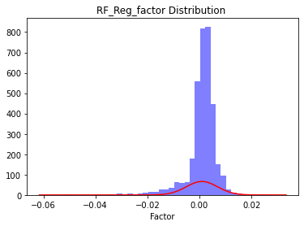

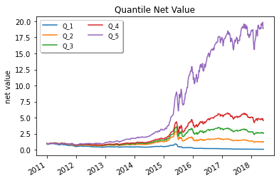

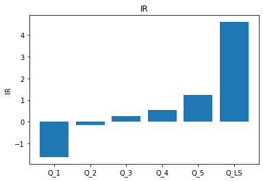

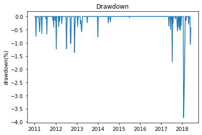

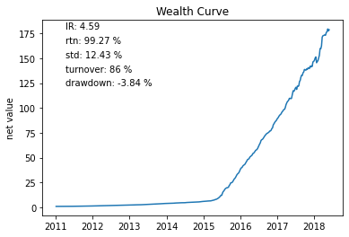

```python
# helper.py has all formulas and plotting functions
%run -i "helper.py"

# backtestlite.py has XXX
%run -i "backtestlite.py"

#set the working directory and some initial parameters.

working_directory = '0 Data/'
#Directory to import the factor you built
factor_path_all = '0 Data/0 New_factors/'

# Define the factor direction, (Descending or Ascending).
# The direction could be observed by the correlation between the factor your built and the stock returns.
# "Descending" if higher factor score, lower return
# "Ascending" if higher factor score, higher return
direction = "Ascending"
###############################################################

# Parameters of backtest.
start = '20110101' # Time horizon, can be vacation, progrmme will extract the maximum subset.
end = '20180601'
quantile = 5
cycle = 5 # Adjustment Cycle (trading frequency), delay for holidays.
win = 48 # 48 weeks in a year
year = 2011 # Beginning year of result display (graphs).

#Import stock 5days forward return.
fwdrtn = pd.read_csv(os.path.join(working_directory, "5DForward.csv"), index_col = 0, parse_dates = True).loc[start:end][::cycle]
#Import market 5days forward return.
mkt_index = pd.read_csv(os.path.join(working_directory, "mkt_5DForward.csv"), index_col = 0, parse_dates = True).loc[str(start):str(end),"SH000905"][::cycle]

#You might want to set trading status (whether it is tradable) when you work on bonus question
status = pd.DataFrame(1, index = fwdrtn.index, columns = fwdrtn.columns)
statuslimit = pd.DataFrame(1, index = fwdrtn.index, columns = fwdrtn.columns)

# Revise the factor name (name of .csv file)
factor = "RF_Reg_factor"

Type = "LS" # this stand for long-short strategy.
# Don't change this unless you are confident with the codes in backtestlite.py

def singlefactor(factor,factor_path_all,Type,direction,fwdrtn,mkt_index,cycle, start, end, quantile,win,year, statuslimit):
    factor_path = os.path.join(factor_path_all, factor + '.csv')

    Type1 = "LS"
    B = Backtestlite(factor_path, direction, fwdrtn, mkt_index, factor_path_all, cycle, start, end, quantile, statuslimit)
    B.run(Type1)

    # Drawing
    pic = DrawPicture(factor,direction, B.data,  B.fwdrtn, B.data.index , mkt_index,  B.rtn_data, B.coverage, B.turnover, factor_path_all, Type1)
    pic.main(win,year,B.rtn_data.columns)

# Calculate performances and do the plot
singlefactor(factor,factor_path_all,Type, direction,fwdrtn,mkt_index,cycle, start, end, quantile,win,year, statuslimit)
```

# XGBoosting

```python
import xgboost as xgb
from xgboost import plot_importance
from matplotlib import pyplot as plt
from sklearn.datasets import load_boston
from sklearn.metrics import mean_squared_error
from sklearn.model_selection import GridSearchCV
```

```python
X = data.drop(['return'], axis=1)
Y = data['return']
```

```python
param_test = {'max_depth':[5,6,7],'learning_rate':[0.03,0.05,0.1],'n_estimators':list(range(140,200,20))}
grid_search = GridSearchCV(estimator=xgb.XGBRegressor(), param_grid=param_test, cv=4, n_jobs=60, scoring='neg_mean_squared_error')
grid_result=grid_search.fit(X, Y)
print(f'Best:{grid_result.best_score_}using{grid_result.best_params_}','\n')

# The outcome is {'max_depth': 7, 'learning rate': 0.1, 'n_estimators': 180}. But our computer broke down when it saved the result. It is
# regretful that we have no time to run a second time.
```

```python
model = xgb.XGBRegressor(max_depth=7,learning_rate=0.1,n_estimators=180)
model.fit(X, Y)

yhat=data[['return']].copy()
yhat['return']=model.predict(X)
```

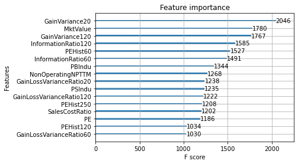

```python
plot_importance(model)
plt.show()
```

```python
temp1=temp[['return']].join(yhat,lsuffix=1)[['return']]

for i in range(return_cut.shape[1]):
    if i == 0:
        factors_reg = temp1[0:return_cut.shape[0]]
        factors_reg.insert(0,'date',return_cut.index)
        factors_reg.set_index(['date'],inplace=True)
    else:
        temp2 = temp1[i*return_cut.shape[0]:(i+1)*return_cut.shape[0]]
        temp2.insert(0,'date',return_cut.index)
        temp2.set_index(['date'],inplace=True)

        factors_reg = pd.concat([factors_reg,temp2],axis=1)

factors_reg.set_axis(return_cut.columns, axis='columns', inplace=True)

save_result_path =  '0 Data/0 new_factors/'
factors_reg.to_csv(os.path.join(save_result_path, 'XGB_factor.csv'))
```

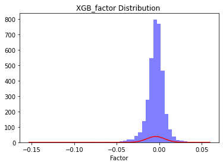

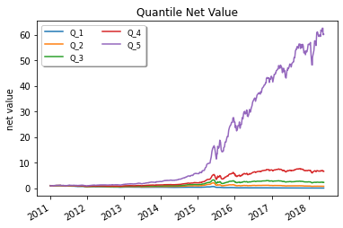

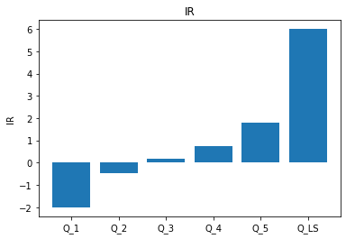

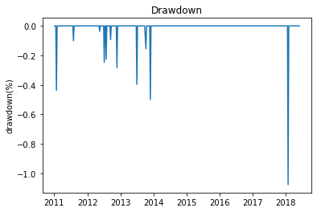

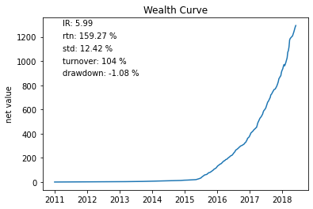

```python
# helper.py has all formulas and plotting functions
%run "helper.py"

# backtestlite.py has XXX
%run "backtestlite.py"

#set the working directory and some initial parameters.

working_directory = '0 Data/'
#Directory to import the factor you built
factor_path_all = '0 Data/0 New_factors/'

# Define the factor direction, (Descending or Ascending).
# The direction could be observed by the correlation between the factor your built and the stock returns.
# "Descending" if higher factor score, lower return
# "Ascending" if higher factor score, higher return
direction = "Ascending"

# Parameters of backtest.
start = '20110101' # Time horizon, can be vacation, progrmme will extract the maximum subset.
end = '20180601'
quantile = 5
cycle = 5 # Adjustment Cycle (trading frequency), delay for holidays.
win = 48 # 48 weeks in a year
year = 2011 # Beginning year of result display (graphs).

#Import stock 5days forward return.
fwdrtn = pd.read_csv(os.path.join(working_directory, "5DForward.csv"), index_col = 0, parse_dates = True).loc[start:end][::cycle]
#Import market 5days forward return.
mkt_index = pd.read_csv(os.path.join(working_directory, "mkt_5DForward.csv"), index_col = 0, parse_dates = True).loc[str(start):str(end),"SH000905"][::cycle]

#You might want to set trading status (whether it is tradable) when you work on bonus question
status = pd.DataFrame(1, index = fwdrtn.index, columns = fwdrtn.columns)
statuslimit = pd.DataFrame(1, index = fwdrtn.index, columns = fwdrtn.columns)

# Revise the factor name (name of .csv file)
factor = "XGB_factor"

Type = "LS" # this stand for long-short strategy.
# Don't change this unless you are confident with the codes in backtestlite.py

def singlefactor(factor,factor_path_all,Type,direction,fwdrtn,mkt_index,cycle, start, end, quantile,win,year, statuslimit):
    factor_path = os.path.join(factor_path_all, factor + '.csv')

    Type1 = "LS"
    B = Backtestlite(factor_path, direction, fwdrtn, mkt_index, factor_path_all, cycle, start, end, quantile, statuslimit)
    B.run(Type1)

    # Drawing
    pic = DrawPicture(factor,direction, B.data,  B.fwdrtn, B.data.index , mkt_index,  B.rtn_data, B.coverage, B.turnover, factor_path_all, Type1)
    pic.main(win,year,B.rtn_data.columns)

# Calculate performances and do the plot
singlefactor(factor,factor_path_all,Type, direction,fwdrtn,mkt_index,cycle, start, end, quantile,win,year, statuslimit)
```

# Bonus Question 2

## Trading frequency

Here we try to change the trading frequency from 5 days to 2 days.

Trading frequency means that the how often we change our portfolio. The default number is 5 days. Correspondingly, we decide to choose two days as the new cycle time, and we assume that shorter period will generate more return.We need to pay attention that if we change the trading frequency, we need to change the cycle time in backtest into two days as well.

```python
csv_path = "0 Data/"
stockclose = "StockClosePrice"
indexclose = "IndexClosePrice"

forward_day = 2 # this should depend on your rolling period

# calculate the forward returns
stock = pd.read_csv(csv_path + stockclose + ".csv", index_col = 0, parse_dates = True)
stockforward = stock.shift(periods = -forward_day, freq = None, axis = 0)
# 5Dforward(t) = (close_price(t+5)-close_price(t))/close_price(t)
stockforwardreturn = (stockforward - stock) / stock
print(stockforwardreturn.head())
stockforwardreturn.to_csv(os.path.join(csv_path, '2DForward.csv')) #stock

# In the simulation,
# you should also calculate indices returns,
# and hedge your portfolio with any one of them.
index = pd.read_csv(csv_path + indexclose + ".csv", index_col = 0, parse_dates = True)
indexforward = index.shift(periods = -forward_day, freq = None, axis = 0)
indexforwardreturn = (indexforward - index) / index
print(indexforwardreturn.head())
indexforwardreturn.to_csv(os.path.join(csv_path, 'mkt_2DForward.csv')) #mkt
```

```
            000001.SZ  000002.SZ  000004.SZ  000005.SZ  000006.SZ  000007.SZ  \
date
2007-01-04  -0.052447  -0.012274   0.022170   0.048580   0.058388   0.076282
2007-01-05   0.056663   0.050506   0.052131   0.059746   0.055433   0.057599
2007-01-08   0.053105   0.122301   0.014445   0.077229   0.035865   0.027552
2007-01-09   0.071013   0.053205   0.042416   0.101488  -0.016834   0.031128
2007-01-10   0.102272  -0.061771   0.047522  -0.003581  -0.078562  -0.034488

            000008.SZ  000009.SZ  000010.SZ  000011.SZ  ...  603987.SH  \
date                                                    ...
2007-01-04   0.045641   0.014236        0.0   0.010995  ...        NaN
2007-01-05   0.035443   0.068903        0.0   0.031398  ...        NaN
2007-01-08   0.108067   0.069897        0.0   0.063537  ...        NaN
2007-01-09   0.187220   0.057737        0.0   0.102148  ...        NaN
2007-01-10  -0.014534  -0.015250        0.0  -0.003460  ...        NaN

            603988.SH  603989.SH  603990.SH  603991.SH  603993.SH  603996.SH  \
date
2007-01-04        NaN        NaN        NaN        NaN        NaN        NaN
2007-01-05        NaN        NaN        NaN        NaN        NaN        NaN
2007-01-08        NaN        NaN        NaN        NaN        NaN        NaN
2007-01-09        NaN        NaN        NaN        NaN        NaN        NaN
2007-01-10        NaN        NaN        NaN        NaN        NaN        NaN

            603997.SH  603998.SH  603999.SH
date
2007-01-04        NaN        NaN        NaN
2007-01-05        NaN        NaN        NaN
2007-01-08        NaN        NaN        NaN
2007-01-09        NaN        NaN        NaN
2007-01-10        NaN        NaN        NaN

[5 rows x 3584 columns]
            SH000001  SH000300  SH000905  SH000906
2007-04-01  0.011154  0.031189  0.074416  0.040633
2007-05-01  0.064545  0.061369  0.068569  0.062976
2007-08-01  0.057641  0.058366  0.047987  0.056047
2007-09-01 -0.002618  0.014336  0.031905  0.018307
2007-10-01 -0.044555 -0.036446 -0.030441 -0.035069
```

```python
#factor_folder = "0 Data/0 Sample_factors/" # I am only using several sample factors here. You should try all factors
factor_folder = "0 Data/0 ALL_factors/"
factor_list = list(set(os.listdir(factor_folder)) - set(['.DS_Store']))
factor_list.sort()
factor_list

# Read all factor files
# Remeber to Z-score the factor values to remove the scale differences
dfs = []
i = 0
for factor in factor_list:
    dfs.append(factor)
    df = pd.read_csv(factor_folder + factor , index_col = 0, parse_dates = True)
    dfs[i] = (df - df.mean()) / df.std()
    i = i + 1

print(dfs[0].head())
```

```
            000001.SZ  000002.SZ  000004.SZ  000005.SZ  000006.SZ  000007.SZ  \
date
2008-01-02  -0.992037  -1.363952  -0.910292   0.025391  -1.526481  -0.743263
2008-01-03  -0.991141  -1.367213  -0.887059   0.039176  -1.522457  -0.715312
2008-01-04  -0.986487  -1.352934  -0.880362   0.028740  -1.518978  -0.720727
2008-01-07  -0.981773  -1.340274  -0.862626   0.057754  -1.512180  -0.707611
2008-01-08  -0.981442  -1.349670  -0.868896   0.042720  -1.519015  -0.733217

            000008.SZ  000009.SZ  000010.SZ  000011.SZ  ...  603987.SH  \
date                                                    ...
2008-01-02  -0.918841  -0.308051        NaN  -1.442556  ...        NaN
2008-01-03  -0.918733  -0.310627        NaN  -1.439407  ...        NaN
2008-01-04  -0.909876  -0.316198        NaN  -1.437608  ...        NaN
2008-01-07  -0.915067  -0.322559        NaN  -1.438576  ...        NaN
2008-01-08  -0.916320  -0.335895        NaN  -1.443508  ...        NaN

            603988.SH  603989.SH  603990.SH  603991.SH  603993.SH  603996.SH  \
date
2008-01-02        NaN        NaN        NaN        NaN        NaN        NaN
2008-01-03        NaN        NaN        NaN        NaN        NaN        NaN
2008-01-04        NaN        NaN        NaN        NaN        NaN        NaN
2008-01-07        NaN        NaN        NaN        NaN        NaN        NaN
2008-01-08        NaN        NaN        NaN        NaN        NaN        NaN

            603997.SH  603998.SH  603999.SH
date
2008-01-02        NaN        NaN        NaN
2008-01-03        NaN        NaN        NaN
2008-01-04        NaN        NaN        NaN
2008-01-07        NaN        NaN        NaN
2008-01-08        NaN        NaN        NaN

[5 rows x 3569 columns]
```

```python
#list all the factors
factors = ['return']
for i in range(len(factor_list)):
    factors.append(factor_list[i][:-4])

#match the data of return and factor
return_cut = stockforwardreturn[dfs[0].columns][dfs[0].index[0]:dfs[0].index[-1]]

#Construct each stock's dataset
data_trans=[]
for i in range(return_cut.shape[1]):
    temp = return_cut.iloc[:,i:i+1]
    data_trans.append(temp)
    for j in range(len(dfs)):
        temp = pd.concat([temp,dfs[j].iloc[:,i:i+1]],axis=1)
    temp.set_axis(factors, axis='columns', inplace=True)
    temp['index']=range(1,len(temp)+1)
    temp['index']=temp['index'].apply(lambda x:str(i+1)+','+str(x))
    temp.set_index(['index'],inplace=True)
    data_trans[i] = temp
```

```python
#concat all the stock's data together
temp=data_trans[0].copy()

for i in range(1,len(data_trans)):
    temp = pd.concat([temp,data_trans[i]],axis=0)

save_result_path =  '0 Data/'
temp.to_csv(os.path.join(save_result_path, 'temp_2D.csv'))
```

```python
data1 = temp.dropna(subset=['return'])

data1.isnull().sum()

data1 = temp.dropna(subset=['return'])

data1.isnull().sum()
```

### Linear Regression

```python
from sklearn import linear_model

#data = temp.dropna()

X = data.drop(['return'], axis=1)
Y = data['return']
```

```python
model = linear_model.LinearRegression()
model.fit(X, Y)

yhat=data[['return']].copy()
yhat['return']=model.predict(X)

temp1=temp[['return']].join(yhat,lsuffix=1)[['return']]

for i in range(return_cut.shape[1]):
    if i == 0:
        factors_reg = temp1[0:return_cut.shape[0]]
        factors_reg.insert(0,'date',return_cut.index)
        factors_reg.set_index(['date'],inplace=True)
    else:
        temp2 = temp1[i*return_cut.shape[0]:(i+1)*return_cut.shape[0]]
        temp2.insert(0,'date',return_cut.index)
        temp2.set_index(['date'],inplace=True)

        factors_reg = pd.concat([factors_reg,temp2],axis=1)

factors_reg.set_axis(return_cut.columns, axis='columns', inplace=True)

save_result_path =  '0 Data/0 new_factors/'
factors_reg.to_csv(os.path.join(save_result_path, 'Linear_Reg_2D_factor.csv'))
```

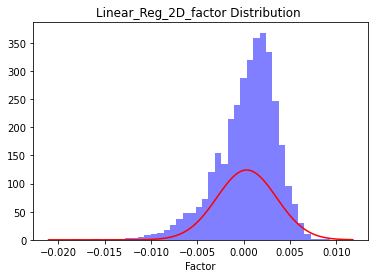

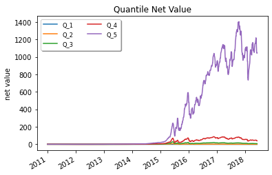

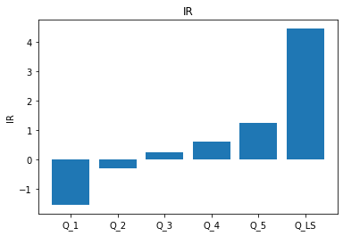

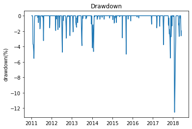

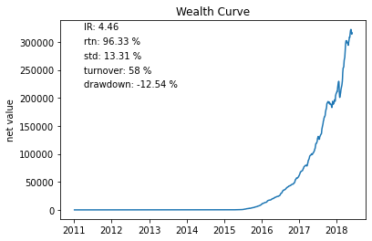

```python
# helper.py has all formulas and plotting functions
%run "helper.py"

# backtestlite.py has XXX
%run "backtestlite.py"

#set the working directory and some initial parameters.

working_directory = '0 Data/'
#Directory to import the factor you built
factor_path_all = '0 Data/0 New_factors/'

# Define the factor direction, (Descending or Ascending).
# The direction could be observed by the correlation between the factor your built and the stock returns.
# "Descending" if higher factor score, lower return
# "Ascending" if higher factor score, higher return
direction = "Ascending"
###############################################################

# Parameters of backtest.
start = '20110101' # Time horizon, can be vacation, progrmme will extract the maximum subset.
end = '20180601'
quantile = 5
cycle = 2 # Adjustment Cycle (trading frequency), delay for holidays.
# Change the cycle time from five days into two days.
win = 48 # 48 weeks in a year
year = 2011 # Beginning year of result display (graphs).

#Import stock 5days forward return.
fwdrtn = pd.read_csv(os.path.join(working_directory, "5DForward.csv"), index_col = 0, parse_dates = True).loc[start:end][::cycle]
#Import market 5days forward return.
mkt_index = pd.read_csv(os.path.join(working_directory, "mkt_5DForward.csv"), index_col = 0, parse_dates = True).loc[str(start):str(end),"SH000905"][::cycle]

#You might want to set trading status (whether it is tradable) when you work on bonus question
status = pd.DataFrame(1, index = fwdrtn.index, columns = fwdrtn.columns)
statuslimit = pd.DataFrame(1, index = fwdrtn.index, columns = fwdrtn.columns)

# Revise the factor name (name of .csv file)
factor = "Linear_Reg_2D_factor"

Type = "LS" # this stand for long-short strategy.
# Don't change this unless you are confident with the codes in backtestlite.py

def singlefactor(factor,factor_path_all,Type,direction,fwdrtn,mkt_index,cycle, start, end, quantile,win,year, statuslimit):
    factor_path = os.path.join(factor_path_all, factor + '.csv')

    Type1 = "LS"
    B = Backtestlite(factor_path, direction, fwdrtn, mkt_index, factor_path_all, cycle, start, end, quantile, statuslimit)
    B.run(Type1)

    # Drawing
    pic = DrawPicture(factor,direction, B.data,  B.fwdrtn, B.data.index , mkt_index,  B.rtn_data, B.coverage, B.turnover, factor_path_all, Type1)
    pic.main(win,year,B.rtn_data.columns)

# Calculate performances and do the plot
singlefactor(factor,factor_path_all,Type, direction,fwdrtn,mkt_index,cycle, start, end, quantile,win,year, statuslimit)
```

Now, comparing the two backtest result, we can see that:

Factor distribution Compared to the graph of 5 days trading frequency, using the same method (linear regression), the factor distribution of linear regression factor is more normally distributed. It has a smaller standard deviation than that of five days.

IR IR graphs are nearly the same, the performance is better.

Drawdown The two days absolute value of drawdown rate is also higher than that of five days.

## Trading Feasibility

In reality, when there is sharp change happening on return of a single stock in Mainland China A share market, up to 10% or -10% in a day, the exchange institute will make a sudden stop on trading, and the limit will continue during the whole day. Although the trading actually can be completed after a long queue rather than being totally prohibited, in our homework, we assume that no trading can be done for that stock on the day in this situation. Considering about this condition, firstly, we calculated the changing rate of the return on the trading day, with the formulation: rate =(close_price(t)-open_price(t))/open_price(t), and save the result in the file with format of csv named by 'rate of stock price changing.csv'

```python
#We add some code in the 'Preparation: Calculate the forward returns for stocks and market indices' part.
#The following is the modified part.

csv_path = "0 Data/"
stockclose = "StockClosePrice"
indexclose = "IndexClosePrice"
stockopen="StockOpenPrice"

#For considering the liminit on trading feasibility, firstly, we calculate the rate of changing on the trading day.
#rate =(close_price(t)-open_price(t))/open_price(t)
stock = pd.read_csv(csv_path + stockclose + ".csv", index_col = 0, parse_dates = True)
stockopen=pd.read_csv(csv_path + stockopen + ".csv", index_col = 0, parse_dates = True)
changingrate=(stock-stockopen)/stockopen
print(changingrate.head())
changingrate.to_csv(os.path.join(csv_path,'rate of stock price changing.csv'))
```

After that, in the process of simulation, we changed the code of ‘status’ by adding the index with ‘rate’, and when the absolute value is larger than 10%, the status of the trading will become ‘0’, meaning that the stock cannot be sold out or bought in.

```python
# The following is the modified part about changing the status limit.

fwdrtn = pd.read_csv(os.path.join(working_directory, "5DForward.csv"), index_col = 0, parse_dates = True).loc[start:end][::cycle]

mkt_index = pd.read_csv(os.path.join(working_directory, "mkt_5DForward.csv"), index_col = 0, parse_dates = True).loc[str(start):str(end),"SH000905"][::cycle]

rate = pd.read_csv(os.path.join(working_directory, "rate of stock price changing.csv"), index_col = 0, parse_dates = True).loc[start:end][::cycle]
#We read and added rate as the parameter to limit the trade feasibility at the rate of +10% and -10%

# We set the index as rate read above and when the absolute value of it is over 10%, the trading will stop
# Meaning that the status of trading equals to 0.
status = pd.DataFrame(1, index = rate.index, columns = rate.columns)
statuslimit = pd.DataFrame(1, index = rate.index, columns = rate.columns)
statuslimit[abs(rate)>0.1]=0
```

Except for the action we have done in the programming as the last paragraph illustrated, we also considered that we should sell the unsold share again in certain time after the special day, while limited by the energy and time, we failed to express this in our code.

## Differentiated Weights

We read the backtestlite.py carefully, and find that in the file the stock are assumed to be trading equally. We want to give more weight to Q_5 as we believe Q_5 perform much better since stocks in Q_5 have higher stock return. So we change the defuction in the backtestlite.py.

What's more, since the XGBoost has the best performance, we use XGBoosting as model and draw a plot of the different factor sorting by importance from highest to lowest. It turns out that marketvalue is important one.

Base on this, we read some paper and find that it is reasonable to combine market value and return stock and give stocks with higher marketvalue more weight.

```python
# The following is the modified part about changing the status limit.

mrt_value = pd.read_csv(os.path.join(factor_folder, "mrt_value.csv"), index_col = 0, parse_dates = True).loc[start:end][::cycle]

# For a certain quantile (choose_quantile), return weight (dataframe)
    def getQuantileWeight(self, choose_quantile):
        weight = pd.DataFrame(0., index = self.rank.index, columns = self.rank.columns)
        weight[(self.rank <= ((choose_quantile * 1.0) / self.quantile)) & (self.rank > ((choose_quantile - 1) / self.quantile))] = 1
        #We want to give more weight to stocks with higher market value in each quantile
        rank_mkt_value = weight.mul(mkt_value, axis = 0)
        weight = rank_mkt_value.div(rank_mkt_value.sum(axis = 1), axis = 0)
        return weight
```

Also, we consider assign weights to each stocks base on sharpe ratio which also take risk into consideration. However, due to time limit, it is hard for us to write code about this part. Usually the method of calculating the Sharpe rate is like this：To simplify the calculation process, we use a month as a cycle and choose U.S. Treasury Interest Rate as rf. We assume st as stock price in t month and calculate ln(st/s(t-1)), and denote this as return, and then calculate the average return, Er and get the sharp ratio as (Er-rf)/std(return).